# 00-Sup-Learning-Capstone-Tree-Methods

### Importing Libaries

```python
import numpy as np
import pandas as pd
import matplotlib.pyplot as plt
import seaborn as sn
```

### Loading the dataset

```python
df = pd.read_csv('Telco-Customer-Churn.csv')
```

#### Showing the first five rows of the dataset

```python
df.head()
```

|  | customerID | gender | SeniorCitizen | Partner | Dependents | tenure | PhoneService | MultipleLines | InternetService | OnlineSecurity | ... | DeviceProtection | TechSupport | StreamingTV | StreamingMovies | Contract | PaperlessBilling | PaymentMethod | MonthlyCharges | TotalCharges | Churn |
| --- | --- | --- | --- | --- | --- | --- | --- | --- | --- | --- | --- | --- | --- | --- | --- | --- | --- | --- | --- | --- | --- |
| 0 | 7590-VHVEG | Female | 0 | Yes | No | 1 | No | No phone service | DSL | No | ... | No | No | No | No | Month-to-month | Yes | Electronic check | 29.85 | 29.85 | No |
| 1 | 5575-GNVDE | Male | 0 | No | No | 34 | Yes | No | DSL | Yes | ... | Yes | No | No | No | One year | No | Mailed check | 56.95 | 1889.50 | No |
| 2 | 3668-QPYBK | Male | 0 | No | No | 2 | Yes | No | DSL | Yes | ... | No | No | No | No | Month-to-month | Yes | Mailed check | 53.85 | 108.15 | Yes |
| 3 | 7795-CFOCW | Male | 0 | No | No | 45 | No | No phone service | DSL | Yes | ... | Yes | Yes | No | No | One year | No | Bank transfer (automatic) | 42.30 | 1840.75 | No |
| 4 | 9237-HQITU | Female | 0 | No | No | 2 | Yes | No | Fiber optic | No | ... | No | No | No | No | Month-to-month | Yes | Electronic check | 70.70 | 151.65 | Yes |

5 rows × 21 columns

#### Showing Total Dataset information

```python
df.info()
```

```
<class 'pandas.core.frame.DataFrame'>
RangeIndex: 7032 entries, 0 to 7031
Data columns (total 21 columns):
 #   Column            Non-Null Count  Dtype
---  ------            --------------  -----
 0   customerID        7032 non-null   object
 1   gender            7032 non-null   object
 2   SeniorCitizen     7032 non-null   int64
 3   Partner           7032 non-null   object
 4   Dependents        7032 non-null   object
 5   tenure            7032 non-null   int64
 6   PhoneService      7032 non-null   object
 7   MultipleLines     7032 non-null   object
 8   InternetService   7032 non-null   object
 9   OnlineSecurity    7032 non-null   object
 10  OnlineBackup      7032 non-null   object
 11  DeviceProtection  7032 non-null   object
 12  TechSupport       7032 non-null   object
 13  StreamingTV       7032 non-null   object
 14  StreamingMovies   7032 non-null   object
 15  Contract          7032 non-null   object
 16  PaperlessBilling  7032 non-null   object
 17  PaymentMethod     7032 non-null   object
 18  MonthlyCharges    7032 non-null   float64
 19  TotalCharges      7032 non-null   float64
 20  Churn             7032 non-null   object
dtypes: float64(2), int64(2), object(17)
memory usage: 1.1+ MB
```

#### Showing Extra statistical measures

```python
df.describe()
```

|  | SeniorCitizen | tenure | MonthlyCharges | TotalCharges |
| --- | --- | --- | --- | --- |
| count | 7032.000000 | 7032.000000 | 7032.000000 | 7032.000000 |
| mean | 0.162400 | 32.421786 | 64.798208 | 2283.300441 |
| std | 0.368844 | 24.545260 | 30.085974 | 2266.771362 |
| min | 0.000000 | 1.000000 | 18.250000 | 18.800000 |
| 25% | 0.000000 | 9.000000 | 35.587500 | 401.450000 |
| 50% | 0.000000 | 29.000000 | 70.350000 | 1397.475000 |
| 75% | 0.000000 | 55.000000 | 89.862500 | 3794.737500 |
| max | 1.000000 | 72.000000 | 118.750000 | 8684.800000 |

# A) Exploratory Data Analysis

### Showing if any null values are present in here or not.

```python
df.isnull().sum()
```

```
customerID          0
gender              0
SeniorCitizen       0
Partner             0
Dependents          0
tenure              0
PhoneService        0
MultipleLines       0
InternetService     0
OnlineSecurity      0
OnlineBackup        0
DeviceProtection    0
TechSupport         0
StreamingTV         0
StreamingMovies     0
Contract            0
PaperlessBilling    0
PaymentMethod       0
MonthlyCharges      0
TotalCharges        0
Churn               0
dtype: int64
```

### Displaying the balance of the class labels (Churn) with a Count Plot.

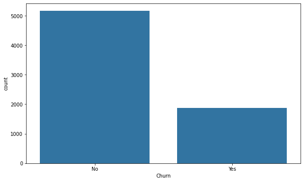

```python
plt.figure(figsize=(10,6))
sn.countplot(x='Churn',data=df)
```

### i) Exploring the distrbution of TotalCharges between Churn categories with a Box Plot or Violin Plot.

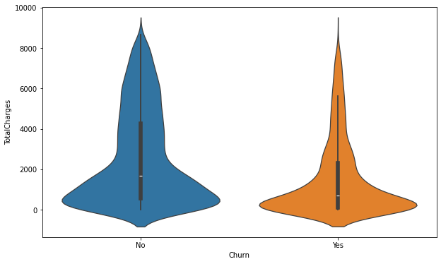

```python
plt.figure(figsize=(10,6))
sn.violinplot(y='TotalCharges',x='Churn',data=df, hue='Churn')
```

### ii) Creating a boxplot showing the distribution of TotalCharges per Contract type, also add in a hue coloring based on the Churn class.

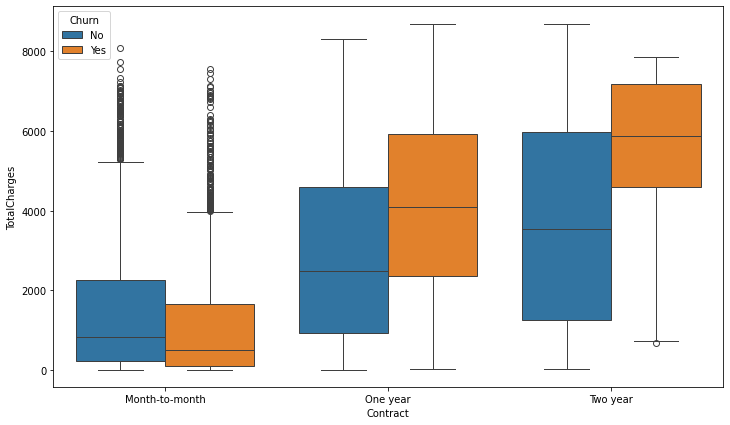

```python
plt.figure(figsize=(12,7))
sn.boxplot(y='TotalCharges',x='Contract',hue='Churn',data=df)
```

### iii) Creating a bar plot showing the correlation of the following features to the class label. Keep in mind, for the categorical features, you will need to convert them into dummy variables first, as you can only calculate correlation for numeric features.

```
['gender', 'SeniorCitizen', 'Partner', 'Dependents','PhoneService', 'MultipleLines',
 'OnlineSecurity', 'OnlineBackup', 'DeviceProtection', 'TechSupport', 'InternetService',
   'StreamingTV', 'StreamingMovies', 'Contract', 'PaperlessBilling', 'PaymentMethod']
```

*Note, we specifically listed only the features above, you should not check the correlation for every feature, as some features have too many unique instances for such an analysis, such as customerID*

```python
df_dummies=pd.get_dummies(df[['gender', 'SeniorCitizen', 'Partner', 'Dependents','PhoneService', 'MultipleLines',
 'OnlineSecurity', 'OnlineBackup', 'DeviceProtection', 'TechSupport', 'InternetService',
   'StreamingTV', 'StreamingMovies', 'Contract', 'PaperlessBilling', 'PaymentMethod','Churn']]).corr()
```

```python
df.columns
```

```
Index(['customerID', 'gender', 'SeniorCitizen', 'Partner', 'Dependents',
       'tenure', 'PhoneService', 'MultipleLines', 'InternetService',
       'OnlineSecurity', 'OnlineBackup', 'DeviceProtection', 'TechSupport',
       'StreamingTV', 'StreamingMovies', 'Contract', 'PaperlessBilling',
       'PaymentMethod', 'MonthlyCharges', 'TotalCharges', 'Churn'],
      dtype='object')
```

```python
df_dummies['Churn_Yes'].sort_values().iloc[1:-1]
```

```
Contract_Two year                         -0.301552
DeviceProtection_No internet service      -0.227578
StreamingMovies_No internet service       -0.227578
StreamingTV_No internet service           -0.227578
InternetService_No                        -0.227578
TechSupport_No internet service           -0.227578
OnlineBackup_No internet service          -0.227578
OnlineSecurity_No internet service        -0.227578
PaperlessBilling_No                       -0.191454
Contract_One year                         -0.178225
OnlineSecurity_Yes                        -0.171270
TechSupport_Yes                           -0.164716
Dependents_Yes                            -0.163128
Partner_Yes                               -0.149982
PaymentMethod_Credit card (automatic)     -0.134687
InternetService_DSL                       -0.124141
PaymentMethod_Bank transfer (automatic)   -0.118136
PaymentMethod_Mailed check                -0.090773
OnlineBackup_Yes                          -0.082307
DeviceProtection_Yes                      -0.066193
MultipleLines_No                          -0.032654
MultipleLines_No phone service            -0.011691
PhoneService_No                           -0.011691
gender_Male                               -0.008545
gender_Female                              0.008545
PhoneService_Yes                           0.011691
MultipleLines_Yes                          0.040033
StreamingMovies_Yes                        0.060860
StreamingTV_Yes                            0.063254
StreamingTV_No                             0.128435
StreamingMovies_No                         0.130920
Partner_No                                 0.149982
SeniorCitizen                              0.150541
Dependents_No                              0.163128
PaperlessBilling_Yes                       0.191454
DeviceProtection_No                        0.252056
OnlineBackup_No                            0.267595
PaymentMethod_Electronic check             0.301455
InternetService_Fiber optic                0.307463
TechSupport_No                             0.336877
OnlineSecurity_No                          0.342235
Contract_Month-to-month                    0.404565
Name: Churn_Yes, dtype: float64
```

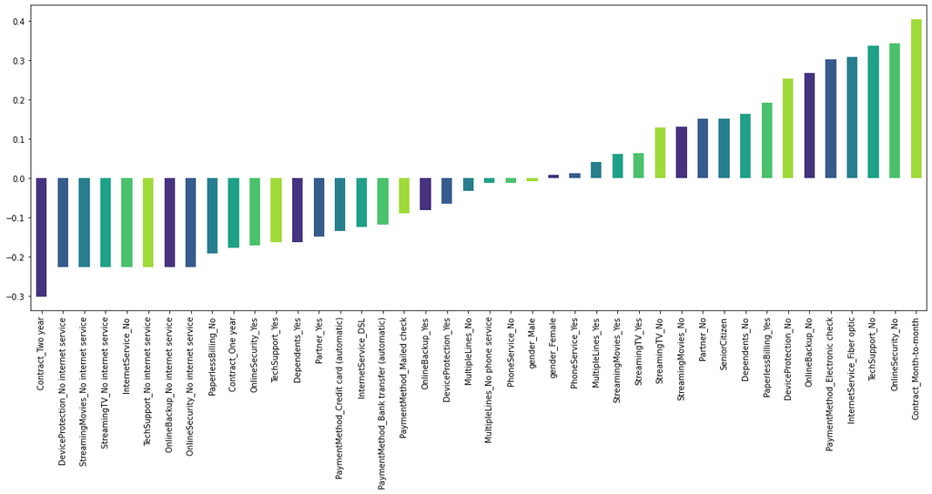

```python
df_dummies['Churn_Yes'].sort_values().iloc[1:-1].plot(kind='bar', figsize=(20,7),color=sn.color_palette('viridis'))
```

# B) Churn Analysis

**This section focuses on segementing customers based on their tenure, creating "cohorts", allowing us to examine differences between customer cohort segments.**

### i) What are the 3 contract types available?

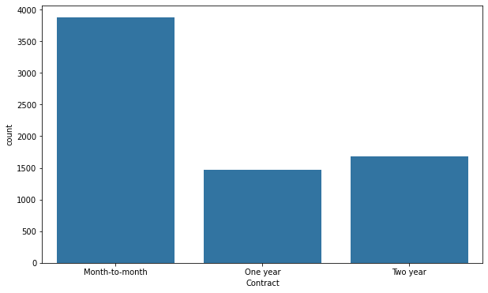

```python
plt.figure(figsize=(10,6))
sn.countplot(x='Contract',data=df)
```

```python
df['Contract'].unique()
```

```
array(['Month-to-month', 'One year', 'Two year'], dtype=object)
```

### ii) Creating a histogram displaying the distribution of 'tenure' column, which is the amount of months a customer was or has been on a customer.

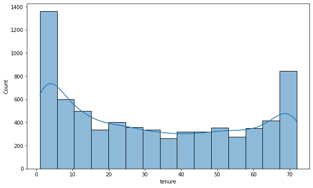

```python
plt.figure(figsize=(10,6))
sn.histplot(x='tenure',data=df,kde=True)
```

### iii) Now using the seaborn documentation as a guide to create histograms separated by two additional features, Churn and Contract.

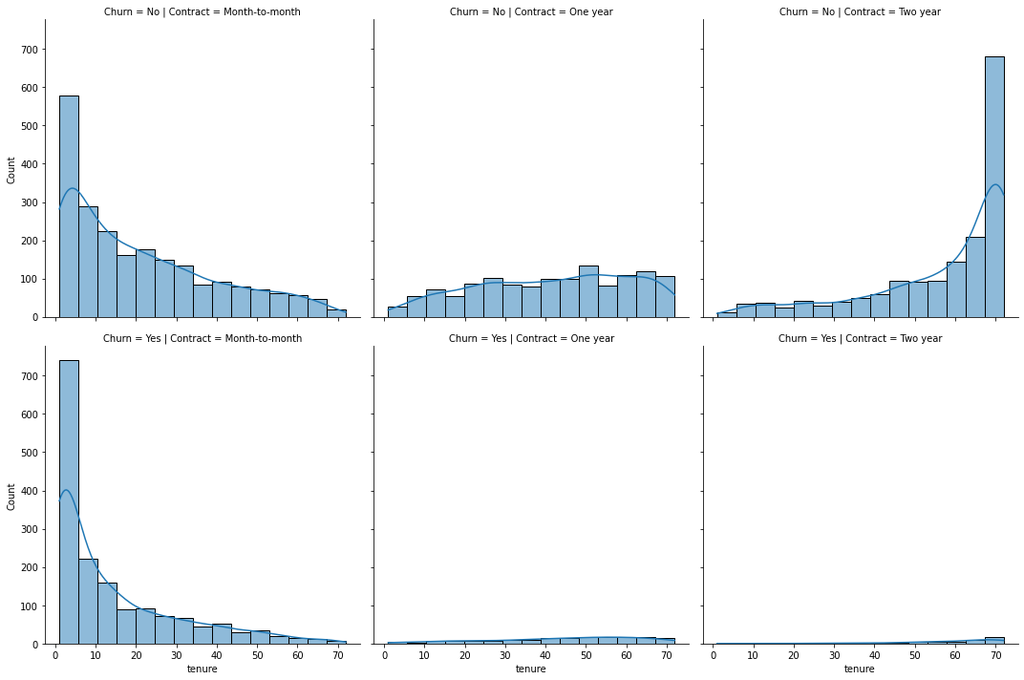

```python
plt.figure(figsize=(10,6))
sn.displot(x='tenure',data=df,kde=True, row='Churn',col='Contract')
```

### iv) Displaying a scatter plot of Total Charges versus Monthly Charges, and color hue by Churn.

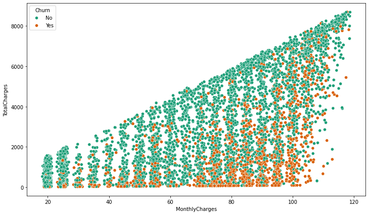

```python
plt.figure(figsize=(12,7))
sn.scatterplot(y='TotalCharges',x='MonthlyCharges',data=df, hue='Churn',palette='Dark2')
```

```python
df.columns
```

```
Index(['customerID', 'gender', 'SeniorCitizen', 'Partner', 'Dependents',
       'tenure', 'PhoneService', 'MultipleLines', 'InternetService',
       'OnlineSecurity', 'OnlineBackup', 'DeviceProtection', 'TechSupport',
       'StreamingTV', 'StreamingMovies', 'Contract', 'PaperlessBilling',
       'PaymentMethod', 'MonthlyCharges', 'TotalCharges', 'Churn'],
      dtype='object')
```

### v) Creating Cohorts based on Tenure

**Let's begin by treating each unique tenure length, 1 month, 2 month, 3 month...N months as its own cohort.**

```python
no_churn=df.groupby(['Churn','tenure']).count().transpose()['No']
yes_churn=df.groupby(['Churn','tenure']).count().transpose()['Yes']
```

```python
churn_rate= 100 * yes_churn/(no_churn+yes_churn)
```

```python
churn_rate.transpose()['customerID']
```

```
tenure
1     61.990212
2     51.680672
3     47.000000
4     47.159091
5     48.120301
        ...
68     9.000000
69     8.421053
70     9.243697
71     3.529412
72     1.657459
Name: customerID, Length: 72, dtype: float64
```

### vi) Now that we have Churn Rate per tenure group 1-72 months, we will create a plot showing churn rate per months of tenure.

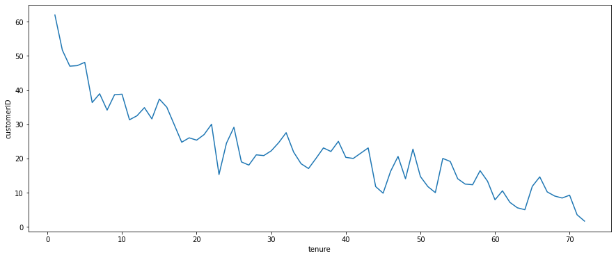

```python
plt.figure(figsize=(15,6))
sn.lineplot(churn_rate.transpose()['customerID'])
```

### vii) Broader Cohort Groups

**Based on the tenure column values, we will create a new column called Tenure Cohort that creates 4 separate categories:**

- '0-12 Months'
- '12-24 Months'
- '24-48 Months'
- 'Over 48 Months'

```python
def cohort(tenure):
    if tenure< 13:
        return '0-12 Months'
    elif tenure<25:
        return '12-24 Months'
    elif tenure< 49:
        return '24-48 Months'
    else:
        return "Over 48 Months"
```

```python
df['Tenure Cohort']=df['tenure'].apply(cohort)
```

```python
df.head(10)[['tenure','Tenure Cohort']]
```

|  | tenure | Tenure Cohort |
| --- | --- | --- |
| 0 | 1 | 0-12 Months |
| 1 | 34 | 24-48 Months |
| 2 | 2 | 0-12 Months |
| 3 | 45 | 24-48 Months |
| 4 | 2 | 0-12 Months |
| 5 | 8 | 0-12 Months |
| 6 | 22 | 12-24 Months |
| 7 | 10 | 0-12 Months |
| 8 | 28 | 24-48 Months |
| 9 | 62 | Over 48 Months |

### viii) A scatterplot of Total Charges versus Monthly Charts,colored by Tenure Cohort defined in the previous task.

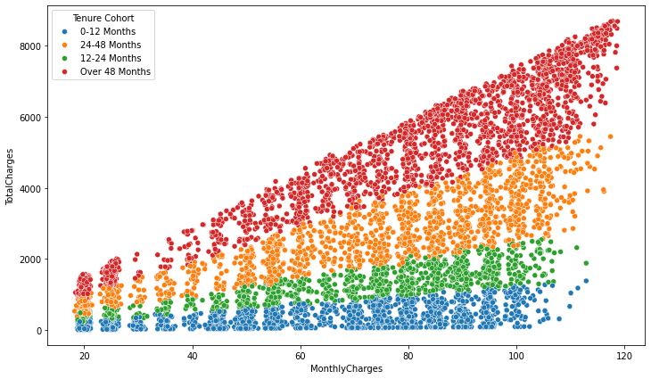

```python
plt.figure(figsize=(12,7))
sn.scatterplot(y='TotalCharges',x='MonthlyCharges',data=df, hue='Tenure Cohort')
```

### ix) A count plot showing the churn count per cohort.**

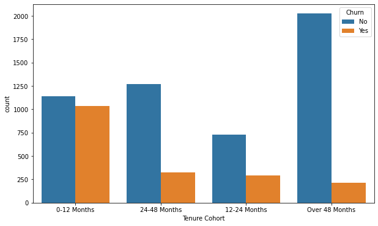

```python
plt.figure(figsize=(10,6))
sn.countplot(x='Tenure Cohort', hue='Churn', data=df)
```

### x) A grid of Count Plots showing counts per Tenure Cohort, separated out by contract type and colored by the Churn hue.

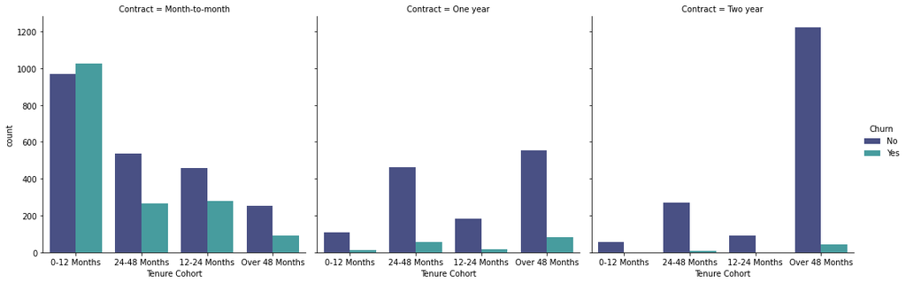

```python
plt.figure(figsize=(10,6))
sn.catplot(x='Tenure Cohort', data=df,  hue='Churn', col='Contract', kind='count', palette='mako')
```

# C) Dealing with Categorical values

```python
X=df.drop(['Churn','customerID'], axis=1)
Y=df['Churn']
```

#### We are using pd.get_dummies instead of Label Encoding

```python
X=pd.get_dummies(X, drop_first=True)
```

# D) Train Test Split

```python
from sklearn.model_selection import train_test_split
```

```python
X_train,X_test,Y_train,Y_test=train_test_split(X,Y,test_size=0.1, random_state=101)
```

```python
print(X.shape,X_train.shape,X_test.shape)
```

```
(7032, 33) (6328, 33) (704, 33)
```

```python
from sklearn.metrics import accuracy_score,classification_report,confusion_matrix
```

# E) Model Training

## 1) Single Decision Tree

```python
from sklearn.tree import DecisionTreeClassifier
```

```python
tree=DecisionTreeClassifier(max_depth=6)
tree.fit(X_train,Y_train)
```

```
DecisionTreeClassifier(max_depth=6)
```

### 1) Model Evaluation

1. **Accuracy Score**

```python
y_pred=tree.predict(X_test)
test_acc=accuracy_score(Y_test,y_pred)

test_acc
```

```
0.8082386363636364
```

1. **Classification Report**

```python
print(classification_report(Y_test,y_pred))
```

```
              precision    recall  f1-score   support

          No       0.87      0.89      0.88       557
         Yes       0.55      0.49      0.52       147

    accuracy                           0.81       704
   macro avg       0.71      0.69      0.70       704
weighted avg       0.80      0.81      0.80       704
```

1. **Confusion Matrix**

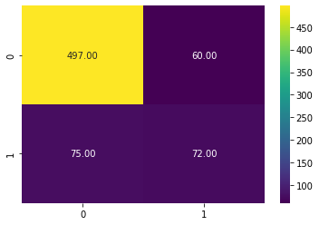

```python
sn.heatmap(confusion_matrix(Y_test,y_pred),annot=True, cmap='viridis',fmt='.2f')
```

```python
tree.feature_importances_
```

```
array([0.01082504, 0.42391407, 0.04348553, 0.06679759, 0.00123697,
       0.        , 0.        , 0.00088963, 0.00696195, 0.01243191,
       0.31406016, 0.        , 0.        , 0.00837585, 0.02628952,
       0.00534132, 0.        , 0.        , 0.        , 0.00786752,
       0.        , 0.        , 0.        , 0.        , 0.01002118,
       0.02706543, 0.        , 0.        , 0.03443632, 0.        ,
       0.        , 0.        , 0.        ])
```

1. **Feature Importance**

```python
tree_f_imt=pd.DataFrame({'Col names':X.columns, 'Feature Importance':tree.feature_importances_}).sort_values('Feature Importance')
```

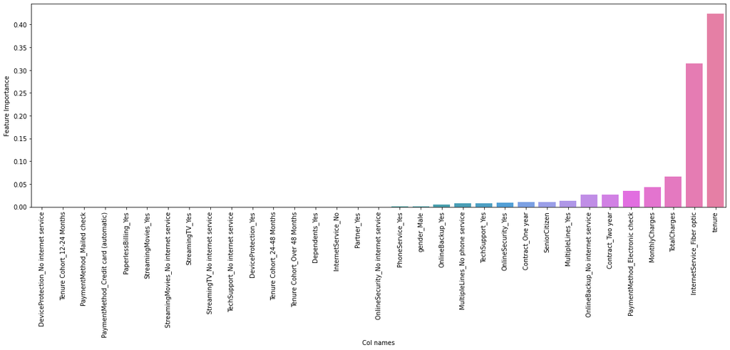

```python
plt.figure(figsize=(20,6))
sn.barplot(x=tree_f_imt['Col names'], y=tree_f_imt['Feature Importance'],palette='husl')
plt.xticks(rotation=90)
plt.show()
```

## a) Plotting the Tree

```python
import warnings
warnings.filterwarnings("ignore")
```

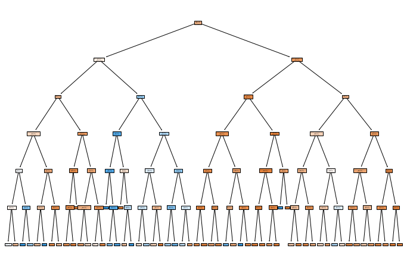

```python
from sklearn.tree import plot_tree
plt.figure(figsize=(12,8))
plot_tree(tree, filled=True, feature_names=X.columns);
```

## 2) Random Forest

**TASK: Create a Random Forest model and create a classification report and confusion matrix from its predicted results on the test set.**

```python
from sklearn.ensemble import RandomForestClassifier
```

```python
rf=RandomForestClassifier(n_estimators=10, max_depth=6,random_state=42)
rf.fit(X_train,Y_train)
```

```
RandomForestClassifier(max_depth=6, n_estimators=10, random_state=42)
```

### 2) Model Evaluation

1. **Accuracy Score**

```python
y_pred=rf.predict(X_test)
test_acc=accuracy_score(Y_test,y_pred)

test_acc
```

```
0.8224431818181818
```

1. **Classification Report**

```python
print(classification_report(Y_test,y_pred))
```

```
              precision    recall  f1-score   support

          No       0.87      0.92      0.89       557
         Yes       0.60      0.46      0.52       147

    accuracy                           0.82       704
   macro avg       0.73      0.69      0.71       704
weighted avg       0.81      0.82      0.81       704
```

1. **Confusion Matrix**

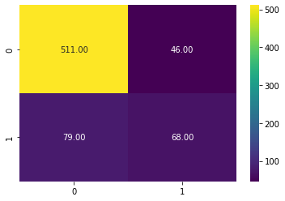

```python
sn.heatmap(confusion_matrix(Y_test,y_pred),annot=True, cmap='viridis',fmt='.2f')
```

1. **Feature Importance**

```python
r_f_imt=pd.DataFrame({'Col names':X.columns, 'Feature Importance':rf.feature_importances_}).sort_values('Feature Importance')
```

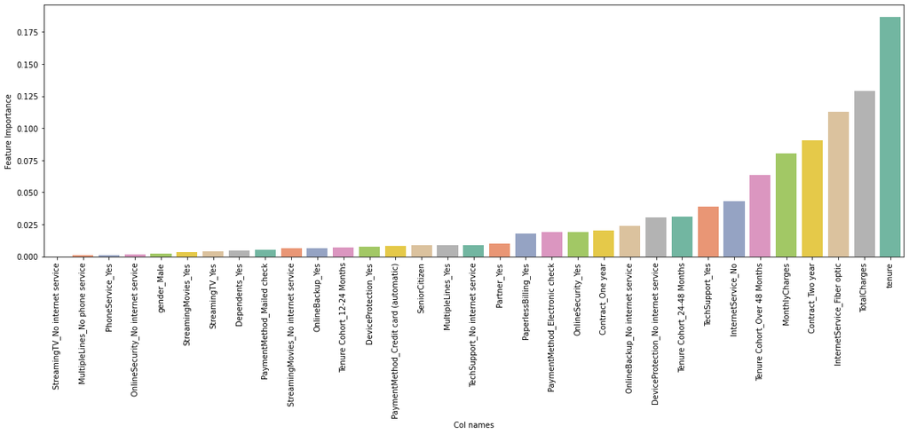

```python
plt.figure(figsize=(20,6))
sn.barplot(x=r_f_imt['Col names'], y=r_f_imt['Feature Importance'],palette='Set2')
plt.xticks(rotation=90)
plt.show()
```

## 3) Boosted Trees

**TASK: Use AdaBoost or Gradient Boosting to create a model and report back the classification report and plot a confusion matrix for its predicted results**

```python
from sklearn.ensemble import GradientBoostingClassifier
```

```python
gc=GradientBoostingClassifier()
gc.fit(X_train,Y_train)
```

```
GradientBoostingClassifier()
```

### 3) Model Evaluation

1. **Accuracy Score**

```python
y_pred=gc.predict(X_test)
test_acc=accuracy_score(Y_test,y_pred)

test_acc
```

```
0.8181818181818182
```

1. **Classification Report**

```python
print(classification_report(Y_test,y_pred))
```

```
              precision    recall  f1-score   support

          No       0.87      0.90      0.89       557
         Yes       0.57      0.50      0.53       147

    accuracy                           0.82       704
   macro avg       0.72      0.70      0.71       704
weighted avg       0.81      0.82      0.81       704
```

1. **Confusion Matrix**

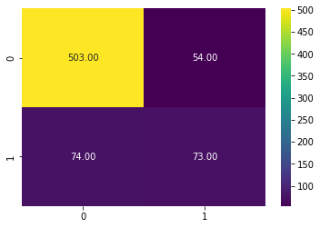

```python
sn.heatmap(confusion_matrix(Y_test,y_pred),annot=True, cmap='viridis',fmt='.2f')
```

1. **Feature Importance**

```python
g_c_imt=pd.DataFrame({'Col names':X.columns, 'Feature Importance':gc.feature_importances_}).sort_values('Feature Importance')
```

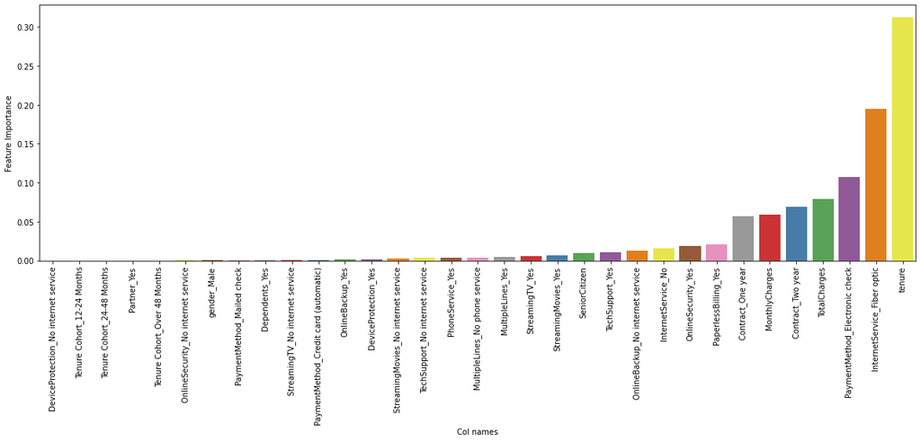

```python
plt.figure(figsize=(20,6))
sn.barplot(x=g_c_imt['Col names'], y=g_c_imt['Feature Importance'], palette='Set1')
plt.xticks(rotation=90)
plt.show()
```